# Pemodelan Kondisi Jalan di Indonesia menggunakan Regresi Linear Berganda

Data diambil dari [Open Data PUPR](https://data.pu.go.id/search/type/dataset) dan [Badan Pusat Statistik](https://www.bps.go.id/id).

Untuk Pemodelan ini yang menjadi variabel respon dan prediktornya adalah

Variabel Respon :

1. Kondisi_Baik

Variabel Prediktor :

1. Jumlah Kendaraan Bermotor - Jumlah
2. Produk Domestik Regional Bruto per Kapita HB (Rp)
3. Jumlah Bencana Alam - Banjir

Pemodelan Kondisi Jalan di Indonesia

**1. Mengimpor Data Kondisi Jalan di Indonesia dalam Format .csv**

```r
# Mengambil Data
data_jalan = read.csv('C:/Users/dedyp/OneDrive - Politeknik Elektronika Negeri Surabaya/Documents/CSV File/Kondisi-Permukaan-Jalan-Kabupaten-dan-Kota-Tahun-2023_new.csv')

# Menampilkan Data
print(head(data_jalan))
```

```
##   Kd_Prov         Provinsi Kondisi_Baik Baik_. Kondisi_Sedang Sedang_.
## 1      11             Aceh      7983.88  45.02        1642.85     9.26
## 2      12   Sumatera Utara     10665.69  34.76        6489.18    21.15
## 3      13   Sumatera Barat      8198.87  45.80        2632.42    14.70
## 4      14             Riau      6850.71  34.65        3462.31    17.51
## 5      15            Jambi      3047.53  30.35        1325.95    13.21
## 6      16 Sumatera Selatan      5800.66  39.96        2925.08    20.15
##   Kondisi_RR  RR_. Kondisi_RB  RB_. Total_Panjang
## 1    3339.75 18.83    4767.05 26.88      17733.53
## 2    2431.77  7.92   11099.22 36.17      30685.86
## 3    1927.24 10.77    5144.09 28.73      17902.62
## 4    5665.98 28.65    3794.97 19.19      19773.97
## 5    2194.18 21.85    3472.50 34.59      10040.16
## 6    2459.92 16.95    3330.17 22.94      14515.83
##   Jumlah.Kendaraan.Bermotor...Jumlah
```

[output cut: 20 more lines]

**2. Melihat Tipe Data pada Data Kondisi Jalan**

```r
# Melihat Tipe Data
print(str(data_jalan))
```

```
## 'data.frame':    37 obs. of  14 variables:
##  $ Kd_Prov                                          : int  11 12 13 14 15 16 17 18 19 21 ...
##  $ Provinsi                                         : chr  "Aceh" "Sumatera Utara" "Sumatera Barat" "Riau" ...
##  $ Kondisi_Baik                                     : num  7984 10666 8199 6851 3048 ...
##  $ Baik_.                                           : num  45 34.8 45.8 34.6 30.4 ...
##  $ Kondisi_Sedang                                   : num  1643 6489 2632 3462 1326 ...
##  $ Sedang_.                                         : num  9.26 21.15 14.7 17.51 13.21 ...
##  $ Kondisi_RR                                       : num  3340 2432 1927 5666 2194 ...
##  $ RR_.                                             : num  18.83 7.92 10.77 28.65 21.85 ...
##  $ Kondisi_RB                                       : num  4767 11099 5144 3795 3472 ...
##  $ RB_.                                             : num  26.9 36.2 28.7 19.2 34.6 ...
##  $ Total_Panjang                                    : num  17734 30686 17903 19774 10040 ...
##  $ Jumlah.Kendaraan.Bermotor...Jumlah               : int  2606048 7798125 2979897 4526046 2726756 4212799 1198609 4115077 1215787 1480436 ...
##  $ Produk.Domestik.Regional.Bruto.per.Kapita.HB..Rp.: int  41424 68306 54327 154522 79836 71950 46285 48194 67885 154179 ...
##  $ Jumlah.Bencana.Alam...Banjir                     : int  97 112 72 79 24 28 11 19 12 11 ...
## NULL
```

Dari hasil dapat dilihat variabel yang akan kita gunakan ada yang bertipe data integer oleh karena itu variabel tersebut akan diubah menjadi numeric

```r
# Merubah Tipe Data
data_jalan$Jumlah.Kendaraan.Bermotor...Jumlah = as.numeric(data_jalan$Jumlah.Kendaraan.Bermotor...Jumlah)
data_jalan$Produk.Domestik.Regional.Bruto.per.Kapita.HB..Rp. = as.numeric(data_jalan$Produk.Domestik.Regional.Bruto.per.Kapita.HB..Rp.)
data_jalan$Jumlah.Bencana.Alam...Banjir = as.numeric(data_jalan$Jumlah.Bencana.Alam...Banjir)

# Mengecek Apakah Tipe Data Sudah Berubah
print(str(data_jalan))
```

```
## 'data.frame':    37 obs. of  14 variables:
##  $ Kd_Prov                                          : int  11 12 13 14 15 16 17 18 19 21 ...
##  $ Provinsi                                         : chr  "Aceh" "Sumatera Utara" "Sumatera Barat" "Riau" ...
##  $ Kondisi_Baik                                     : num  7984 10666 8199 6851 3048 ...
##  $ Baik_.                                           : num  45 34.8 45.8 34.6 30.4 ...
##  $ Kondisi_Sedang                                   : num  1643 6489 2632 3462 1326 ...
##  $ Sedang_.                                         : num  9.26 21.15 14.7 17.51 13.21 ...
##  $ Kondisi_RR                                       : num  3340 2432 1927 5666 2194 ...
##  $ RR_.                                             : num  18.83 7.92 10.77 28.65 21.85 ...
##  $ Kondisi_RB                                       : num  4767 11099 5144 3795 3472 ...
##  $ RB_.                                             : num  26.9 36.2 28.7 19.2 34.6 ...
##  $ Total_Panjang                                    : num  17734 30686 17903 19774 10040 ...
##  $ Jumlah.Kendaraan.Bermotor...Jumlah               : num  2606048 7798125 2979897 4526046 2726756 ...
##  $ Produk.Domestik.Regional.Bruto.per.Kapita.HB..Rp.: num  41424 68306 54327 154522 79836 ...
##  $ Jumlah.Bencana.Alam...Banjir                     : num  97 112 72 79 24 28 11 19 12 11 ...
## NULL
```

Dari hasil dapat dilihat bahwa variabel yang akan kita gunakan sudah bertipe data numeric

**3. Menentukan Variabel Regresi**

```r
# Variabel Respon
Y = data_jalan$Kondisi_Baik

# Variabel Prediktor
X1 = data_jalan$Jumlah.Kendaraan.Bermotor...Jumlah
X2 = data_jalan$Produk.Domestik.Regional.Bruto.per.Kapita.HB..Rp.
X3 = data_jalan$Jumlah.Bencana.Alam...Banjir
```

**4. Melakukan Regresi Linear Berganda**

```r
# Menggunakan Semua Variabel
relation <- lm(Y~X1+X2+X3)
print(summary(relation))
```

```
##
## Call:
## lm(formula = Y ~ X1 + X2 + X3)
##
## Residuals:
##     Min      1Q  Median      3Q     Max
## -4916.2  -905.9  -455.6   819.5  5630.8
##
## Coefficients:
##               Estimate Std. Error t value Pr(>|t|)
## (Intercept)  1.770e+03  7.558e+02   2.341  0.02540 *
## X1           5.126e-04  7.344e-05   6.979 5.58e-08 ***
## X2          -7.154e-03  7.643e-03  -0.936  0.35607
## X3           4.011e+01  1.267e+01   3.166  0.00332 **
## ---
## Signif. codes:  0 '***' 0.001 '**' 0.01 '*' 0.05 '.' 0.1 ' ' 1
##
## Residual standard error: 2036 on 33 degrees of freedom
## Multiple R-squared:  0.7879, Adjusted R-squared:  0.7686
## F-statistic: 40.86 on 3 and 33 DF,  p-value: 3.244e-11
```

Dari pengujian pertama menggunakan semua variabel didapat:

1. P-value dari uji serentak sebesar 3.244e-11, dengan menggunakan level signifikan sebesar 5% (0.05) menunjukkan bahwa setidaknya ada satu variabel yang signfikan
2. P-value untuk koefisen X1 dan X3 keduanya memiliki nilai dibawah level signifikan (5%) yaitu 5.58e-08 < 0.05 (X1) dan 0.00332 < 0.05 (X3) menunjukkan bahwa variabel signfikan terhadap variabel Y
3. P-value untuk koefisien X2 memiliki nilai niatas level signifikan (5%) yaitu 0.35607 > 0.05 (X2) menunjukkan bahwa variabel tidak berpengaruh dengan variabel Y
4. Nilai R-squared sebesar 0.7879 artinya variabilitas Kondisi_baik dapat dijelaskan oleh variabel prediktor sebesar 78.79%

Karena variabel X2 tidak signifikan dalam model, maka dicoba kembali dengan menghapus variabel X2

```r
# Tanpa Menggunakan Variabel X2
relation <- lm(Y~X1+X3)
print(summary(relation))
```

```
##
## Call:
## lm(formula = Y ~ X1 + X3)
##
## Residuals:
##     Min      1Q  Median      3Q     Max
## -4836.7  -985.2  -555.8   890.3  5647.5
##
## Coefficients:
##              Estimate Std. Error t value Pr(>|t|)
## (Intercept) 1.231e+03  4.886e+02   2.518   0.0167 *
## X1          5.171e-04  7.315e-05   7.069 3.65e-08 ***
## X3          4.011e+01  1.264e+01   3.173   0.0032 **
## ---
## Signif. codes:  0 '***' 0.001 '**' 0.01 '*' 0.05 '.' 0.1 ' ' 1
##
## Residual standard error: 2032 on 34 degrees of freedom
## Multiple R-squared:  0.7822, Adjusted R-squared:  0.7694
## F-statistic: 61.07 on 2 and 34 DF,  p-value: 5.565e-12
```

Dari pengujian kedua tanpa menggunakan variabel X2 didapat:

1. P-value dari uji serentak sebesar 5.565e-12, dengan menggunakan level signifikan sebesar 5% (0.05) menunjukkan bahwa setidaknya ada satu variabel yang signfikan
2. P-value untuk koefisen X1 dan X3 keduanya memiliki nilai dibawah level signifikan (5%) yaitu 3.65e-08 < 0.05 (X1) dan 0.0032 < 0.05 (X3) menunjukkan bahwa variabel signfikan terhadap variabel Y
3. P-value untuk koefisien intercept memiliki nilai di bawah level signifikan (5%) yaitu 0.0167 < 0.05 menunjukkan bahwa intercept signifikan terhadap variabel Y
4. Nilai R-squared sebesar 0.7822 artinya variabilitas Kondisi_baik dapat dijelaskan oleh variabel prediktor sebesar 78.22%

Dari pengujian kedua dapat dilihat bahwa semua parameter signifikan terhadap model, sehingga didapat persamaan :

**Y = 1.231e+03 + 5.171e-04 X1 + 4.011e+01 X3**

Dari model yang didapat, dapat kita ketahui bahwa

1. Konstanta sebesar 1.231e+03 artinya jika X1 (Jumlah Kendaraan Bermotor) dan X3 (Jumlah Banjir) bernilai 0, maka nilai Y (Kondisi Baik) adalah 1.231e+03
2. Koefisien regresi variabel X1 (Jumlah Kendaraan Bermotor) sebesar 5.171e-04, artinya setiap kenaikan 1 satuan maka ada kecendrungan rata-rata variabel Y (Kondisi Baik) naik sebesar 5.171e-04
3. Koefisien regresi variabel X3 (Jumlah Banjir) sebesar 4.011e+01, artinya setiap kenaikan 1 satuan makan ada kecendrungan rata-rata variabel Y (Kondisi Baik) naik sebesar 4.011e+01

**5. Analisa Residual**

```r
# Menyimpan Nilai Residual
residual=resid(relation)
```

**(1). Uji Normalitas**

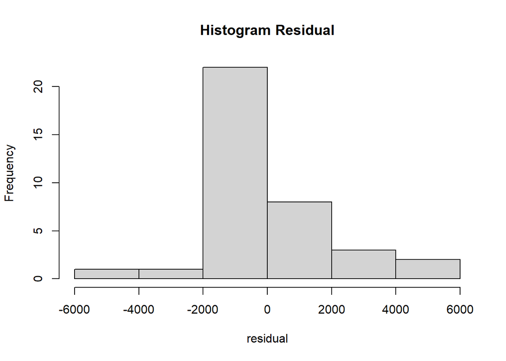

```r
# Melihat Histogram Residual
hist(residual,main="Histogram Residual")
```

Dari Histogram terlihat bahwa

1. Histogram residual tidak terdistribusi secara normal, Sebuah distribusi normal biasanya akan membentuk lonceng simetris
2. Histogram residual memiliki panjang yang ekstrem artinya ada bar yang lebih panjang di satu sisi, yang menunjukkan ada lebih banyak residual yang jauh dari nilai rata-rata di sisi tersebut.

```r
# Uji Kolmogorov-Smirnov
library(nortest)
lillie.test(residual)
```

```
##
##  Lilliefors (Kolmogorov-Smirnov) normality test
##
## data:  residual
## D = 0.15772, p-value = 0.02074
```

Dari Uji Kolmogorov-Smirnov didapat nilai p-value sebesar 0.02074 < 0.05 (5%) yang di mana residual tidak terdistribusi normal

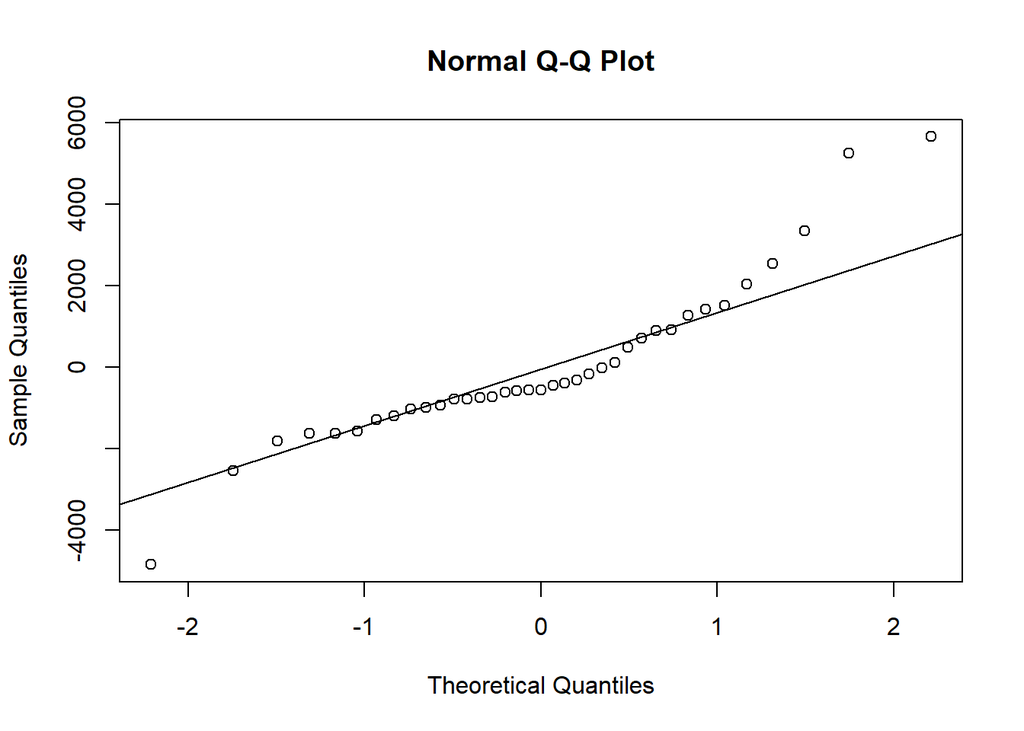

```r
# QQPlot Residual
qqnorm(residual)
qqline(residual)
```

Dari QQPlot dapat dilihat bahwa residual tidak sepenuhnya normal meskipun terdapat kesesuaian ditengah tetapi terdapat dua nilai yang tidak sesuai (Di ujung kanan atas dan di ujung kiri bawah)

**(2). Uji Keragaman Residual**

```r
# Breusch-Pagan test
library(lmtest)
bptest(relation,studentize=F)
```

```
##
##  Breusch-Pagan test
##
## data:  relation
## BP = 9.2076, df = 2, p-value = 0.01001
```

Dari Uji keragaman residual dengan Breusch-Pagan test didapat nilai p-value sebesar 0.01001 < 0.05 (5%) yang di mana residual mempunyai variansi yang tidak konstan

**(3). Uji Independensi Residual**

```r
#Uji Autokorelasi (Durbin Watson)
dwtest(relation)
```

```
##
##  Durbin-Watson test
##
## data:  relation
## DW = 2.1159, p-value = 0.5807
## alternative hypothesis: true autocorrelation is greater than 0
```

Dari Hasil Uji Autokorelasi (Durbin Watson) didapat nilai p-value sebesar 0.5807 > 0.05 (5%) yang di mana tidak ada autokorelasi dari nilai residual

**6. Kesimpulan**